# Pump it up: Data Mining the Water Table

Next, we will analyze the input variables. To do this, we will make use of a library that allows us to obtain a quick view of the histograms of the numerical variables, as well as the existing correlations or missing in our data set.

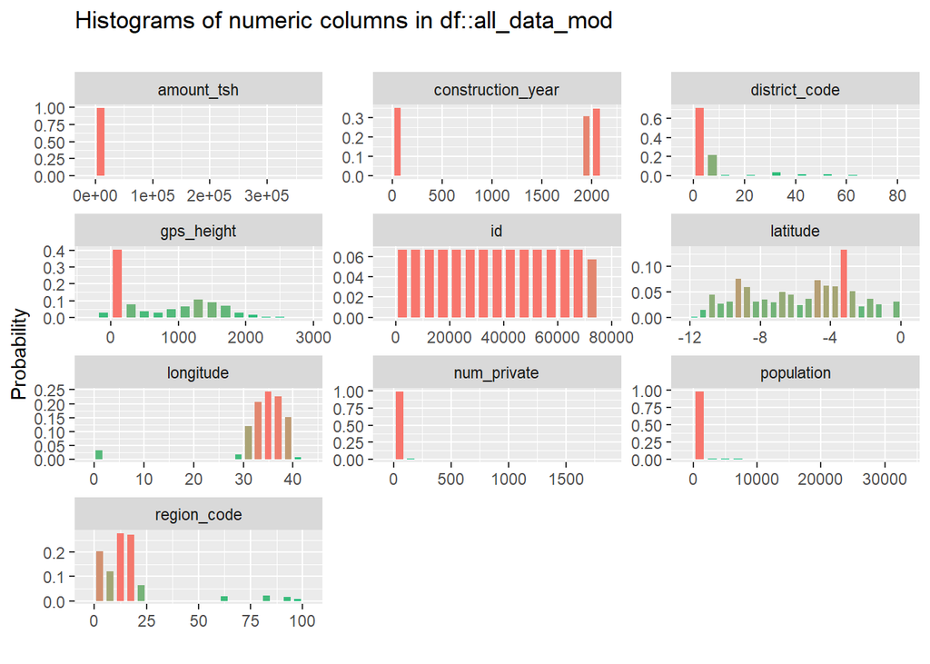

```r
# HISTOGRAMS
x <- inspect_num(all_data_mod)
show_plot(x)
```

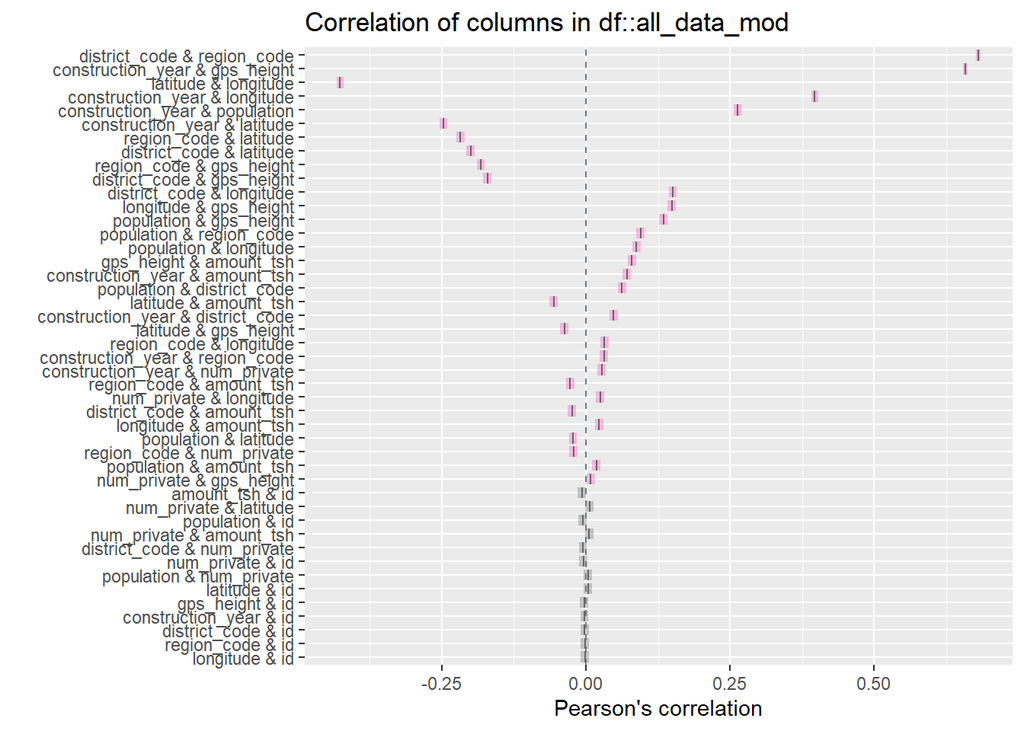

```r
# CORRELATIONS
x <- inspect_cor(all_data_mod)
show_plot(x)
```

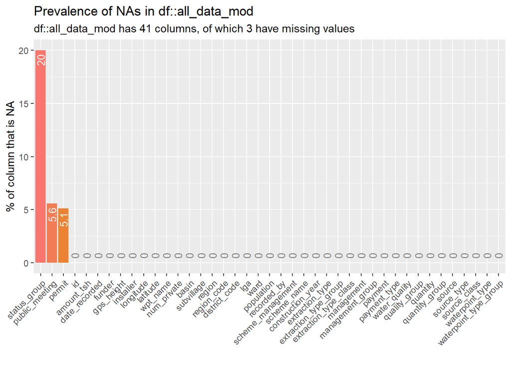

```r
# MISSINGS
x <- inspect_na(all_data_mod)
show_plot(x)
```

We can see how there are variables that will not contribute value to the prediction, such as Id or Num_Private. We can also observe how there are variables with 0s in a disproportionate way, so we may be in the presence of “hidden” missings. In addition, we can see how there are approximately 5% of missings for Public Meeting and Permit (we do not consider status group because when joining Test & Train, Test records have been filled as NAs and this will not be a problem because to finish and generate the model we will separate it again in Train and Test). Finally, we see how there is an interesting correlation between District Code and Region Code so we will have to deal with it.

To conclude this section, we briefly reflect on some of the variables that we mentioned at the beginning and that seemed to be closely related:

```r
# QUANTITY & QUANTITY_GROUP
table(all_data_mod$quantity, all_data_mod$status_group)
```

```
##
##                functional functional needs repair non functional
##   dry                 157                      37           6052
##   enough            21648                    2400           9138
##   insufficient       7916                    1450           5763
##   seasonal           2325                     416           1309
##   unknown             213                      14            562
```

```r
table(all_data_mod$quantity_group, all_data_mod$status_group)
```

```
##
##                functional functional needs repair non functional
##   dry                 157                      37           6052
##   enough            21648                    2400           9138
##   insufficient       7916                    1450           5763
##   seasonal           2325                     416           1309
##   unknown             213                      14            562
```

```r
# PAYMENT & PAYMENT_TYPE
table(all_data_mod$payment, all_data_mod$status_group)
```

```
##
##                         functional functional needs repair non functional
##   never pay                  11379                    1907          12062
##   other                        611                     118            325
##   pay annually                2740                     247            655
##   pay monthly                 5482                     927           1891
##   pay per bucket              6090                     409           2486
##   pay when scheme fails       2429                     277           1208
##   unknown                     3528                     432           4197
```

```r
table(all_data_mod$payment_type, all_data_mod$status_group)
```

```
##
##              functional functional needs repair non functional
##   annually         2740                     247            655
##   monthly          5482                     927           1891
##   never pay       11379                    1907          12062
##   on failure       2429                     277           1208
##   other             611                     118            325
##   per bucket       6090                     409           2486
##   unknown          3528                     432           4197
```

```r
# EXTRACTION / EXTRACTION_TYPE_CLASS, EXTRACTION_TYPE_GROUP
table(all_data_mod$extraction_type, all_data_mod$status_group)
```

```
##
##                             functional functional needs repair non functional
##   afridev                         1200                      42            528
##   cemo                              45                       9             36
##   climax                             8                       0             24
##   gravity                        16048                    2701           8031
##   india mark ii                   1448                      79            873
##   india mark iii                    44                       1             53
##   ksb                              703                      26            686
##   mono                            1082                     129           1654
##   nira/tanira                     5421                     641           2092
##   other                           1029                     206           5195
##   other - mkulima/shinyanga          0                       0              2
##   other - play pump                 29                       1             55
##   other - rope pump                293                      17            141
##   other - swn 81                   120                       7            102
##   submersible                     2626                     227           1911
##   swn 80                          2090                     212           1368
##   walimi                            23                      12             13
##   windmill                          50                       7             60
```

```r
table(all_data_mod$extraction_type_group, all_data_mod$status_group)
```

```
##
##                   functional functional needs repair non functional
##   afridev               1200                      42            528
##   gravity              16048                    2701           8031
##   india mark ii         1448                      79            873
##   india mark iii          44                       1             53
##   mono                  1082                     129           1654
##   nira/tanira           5421                     641           2092
##   other                 1029                     206           5195
##   other handpump         172                      20            172
##   other motorpump         53                       9             60
##   rope pump              293                      17            141
##   submersible           3329                     253           2597
##   swn 80                2090                     212           1368
##   wind-powered            50                       7             60
```

```r
table(all_data_mod$extraction_type_class, all_data_mod$status_group)
```

```
##
##                functional functional needs repair non functional
##   gravity           16048                    2701           8031
##   handpump          10375                     995           5086
##   motorpump          1135                     138           1714
##   other              1029                     206           5195
##   rope pump           293                      17            141
##   submersible        3329                     253           2597
##   wind-powered         50                       7             60
```

We can see how the Quantity & Quantity_group variables are identical, how between payment & payment_type they have the same division of categories with different names or how between the extraction variables the three variables provide more or less information depending on the number of categories.

## DATA CLEANING & FEATURE ENGINEERING

At this stage, we will dedicate ourselves to cleaning the data set as well as creating new variables that may provide us with information to predict the target variable.

#### 1 - We eliminated the variables that were similar, as well as num_private and recorded_by

```r
all_data_mod <- all_data_mod[, - c("payment_type"
                                   ,"extraction_type_class", "extraction_type",
                                   "management",
                                   "quality_group",
                                   "quantity_group",
                                   "source_type", "source_class",
                                   "waterpoint_type_group",
                                   # "id"
                                   "num_private", "recorded_by")]
```

#### 2 - Impute the NAs of public_meeeting & permit to a new variable that we call “Desconocido”.

```r
all_data_mod$permit <- as.character(all_data_mod$permit)
all_data_mod$public_meeting <- as.character(all_data_mod$public_meeting)
all_data_mod$permit[sapply(all_data_mod$permit, is.na)] <- "Desconocido"
all_data_mod$public_meeting[sapply(all_data_mod$public_meeting, is.na)] <- "Desconocido"
all_data_mod$permit <- as.factor(all_data_mod$permit)
all_data_mod$public_meeting <- as.factor(all_data_mod$public_meeting)
```

#### 3 - Modify the date_recorded variable

This variable, in date format, will be converted into two variables: Month and Year. Moreover, in Tanzania it is known that there are seasons depending on how much it rains (Long Rainy seasons) or, on the contrary, months where the climate is very dry. Therefore, we consider that this variable could be of interest.

```r
all_data_mod$fe_anio    <- year(all_data_mod$date_recorded)
all_data_mod$fe_mes     <- month(all_data_mod$date_recorded)

long_rainy_season <- c(3, 4, 5)
long_dry_season <- c(6, 7, 8, 9, 10)
short_dry_season <- c(1,2)
short_rainy_season <- c(11, 12)
all_data_mod$season <- ifelse(all_data_mod$fe_mes %in% long_rainy_season, "Long Rainy", ifelse(all_data_mod$fe_mes  %in% long_dry_season, "Long Dry",
                                                                                               ifelse(all_data_mod$fe_mes  %in% short_dry_season, "Short Dry", "Short Rainy")))

all_data_mod$season <- as.factor(all_data_mod$season)

all_data_mod$date_recorded <- NULL
```

#### 4 - GPS HEIGHT

This variable was observed in the summary() that had negative values and the lowest point of Tanzania is the sea level (0 m) so they are erroneous values.

To impure them we perform a process that we will repeat with other variables such as population. We will group the gps_height data by region and impute the NAs based on the median value for each region. In this way we try to reduce the probability of imputing values that are far away from the real value.

```r
# Impute negative values and 0s (possible NAs) to NA
all_data_mod$gps_height[all_data_mod$gps_height <= 0 ] <- NA

# To refine, we group by region
Region_GPS<- all_data_mod %>%
    group_by(region) %>%
    summarize(re_gps_height = median(gps_height, na.rm = TRUE))

# Some regions have no value (NAs)

Region_GPS$re_gps_height <- ifelse(Region_GPS$region == "Dodoma", 1483,  # Manyara
                                   ifelse(Region_GPS$region == "Kagera", 1295, # Mara
                                          ifelse(Region_GPS$region == "Mbeya",1720, # Iringa
                                                 ifelse(Region_GPS$region == "Tabora", 1274, Region_GPS$re_gps_height)))) # Kigoma

all_data_mod <- merge(all_data_mod, Region_GPS, by = 'region')

all_data_mod$fe_gps_height <- ifelse(is.na(all_data_mod$gps_height), all_data_mod$re_gps_height, all_data_mod$gps_height)

all_data_mod$gps_height <- NULL
all_data_mod$re_gps_height <- NULL
```

#### 5 - DISTRICT CODE & REGION CODE

Since they were highly correlated, we created a new joint variable to eliminate the potential collinearity problem.

```r
all_data_mod$district_region_code <- paste(all_data_mod$district_code, all_data_mod$region_code, sep = "")
all_data_mod$district_region_code  <- as.factor(all_data_mod$district_region_code )

all_data_mod$district_code <- NULL
all_data_mod$region_code <- NULL
```

#### 5 - CONSTRUCTION YEAR

The year of construction of the pump has a very high number of 0s so we consider them as nulls. To solve this problem, we will impute these nulls as a function of the region in which the pump was built.

```r
all_data_mod$construction_year[all_data_mod$construction_year == 0] <- NA

Region_Anio_Construccion<- all_data_mod %>%
    group_by(region) %>%
    summarize(re_anio = median(construction_year, na.rm = TRUE))


Region_Anio_Construccion <- Region_Anio_Construccion %>%
    replace_na(list(re_anio = median(Region_Anio_Construccion$re_anio, na.rm = TRUE) ))


all_data_mod <- merge(all_data_mod, Region_Anio_Construccion, by = 'region')


all_data_mod$fe_anio_construccion <- ifelse(is.na(all_data_mod$construction_year), all_data_mod$re_anio, all_data_mod$construction_year)

all_data_mod$construction_year <- NULL
all_data_mod$re_anio <- NULL
```

#### 6 - PUMP AGE

Knowing the year in which the pump was built together with the year in which a certain record was obtained (date_recorded converted to fe_year), we can obtain the life of the pump which can be interesting to predict the response variable.

```r
all_data_mod$pump_age <- all_data_mod$fe_anio - all_data_mod$fe_anio_construccion

summary(all_data_mod$pump_age)
```

```
##    Min. 1st Qu.  Median    Mean 3rd Qu.    Max.
##   -7.00    7.00   11.00   13.74   16.00   53.00
```

```r
# Los valores negativos los reemplazamos por median
all_data_mod$pump_age <- ifelse(all_data_mod$pump_age < 0 , median(all_data_mod$pump_age), all_data_mod$pump_age)
```

#### 7 - LONGITUDE AND LATITUDE

Tanzania has, approximately, a longitude of 34º while its latitude is slightly negative. With this, we can determine if there are values that do not fit in the data set. In our case, for longitude there are values close to zero so they could be NAs. To impute them, we will do it according to the region as we have done previously with other variables.

Finally, we create a new variable that will be a combination of the two previous ones (the distance).

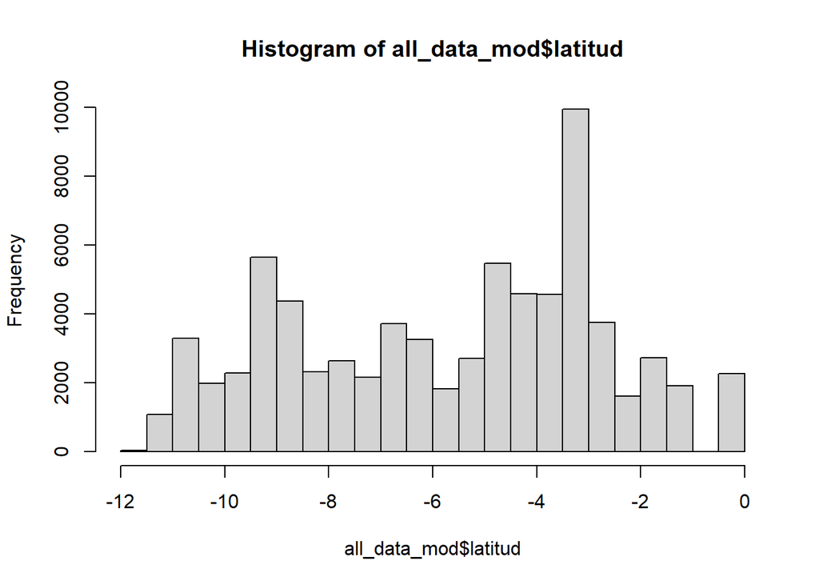

```r
hist(all_data_mod$latitud)
```

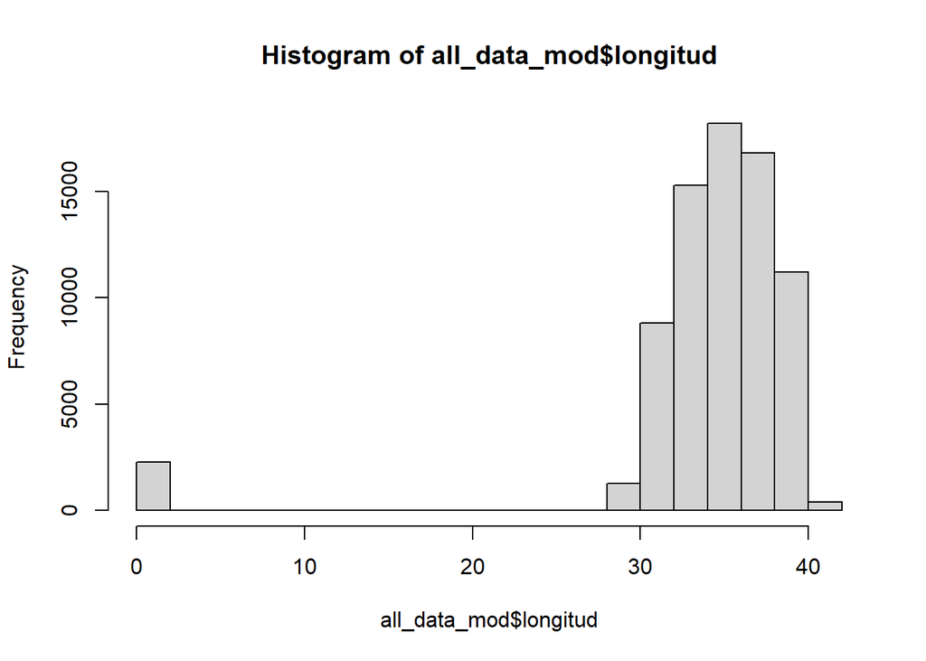

```r
hist(all_data_mod$longitud)
```

```r
all_data_mod$longitude[all_data_mod$longitude == 0] <- NA

Region_Longitude <- all_data_mod %>%
    group_by(region) %>%
    summarize(re_longitude = mean(longitude, na.rm = TRUE))

all_data_mod2 <- copy(all_data_mod)
all_data_mod2 <- merge(all_data_mod2, Region_Longitude, by = 'region')

all_data_mod2$fe_longitude <- ifelse(is.na(all_data_mod2$longitude), all_data_mod2$re_longitude, all_data_mod2$longitude)

all_data_mod2$longitude <- NULL
all_data_mod2$re_longitude <- NULL


all_data_mod2$fe_lonlat <- sqrt(all_data_mod2$fe_longitude^2 + all_data_mod2$latitude^2)
all_data_mod2$fe_longitude <- NULL
all_data_mod2$latitude <- NULL
```

#### 8 - POPULATION

For the population, again, we see how there are values that are 0s. These values will be NAs and, therefore, we must impute them following the above procedure.

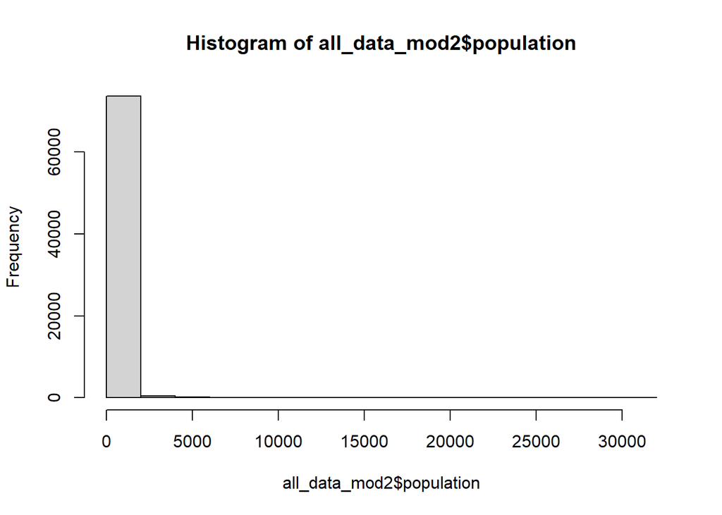

```r
hist(all_data_mod2$population)
```

```r
all_data_mod2$population[all_data_mod2$population == 0] <- NA

Region_Poblacion<- all_data_mod2 %>%
    group_by(region) %>%
    summarize(re_population = median(population, na.rm = TRUE))

Region_Poblacion <- Region_Poblacion %>%
    replace_na(list(re_population = median(Region_Poblacion$re_population, na.rm = TRUE) ))

all_data_mod3 <- copy(all_data_mod2)
all_data_mod3 <- merge(all_data_mod3, Region_Poblacion, by = 'region')
all_data_mod3$fe_population <- ifelse(is.na(all_data_mod3$population), all_data_mod3$re_population, all_data_mod3$population)


all_data_mod3$population <- NULL
all_data_mod3$re_population <- NULL
```

#### 9 - AMOUNT_TSH

In this case, this variable also has 0s like the rest but, nevertheless, given that there is a fairly direct relationship with the target variable, we proceed to eliminate it from the dataset since if we were to try to impute it following the previous procedure, we might generate a biased model.

```r
all_data_mod4 <- copy(all_data_mod3)

all_data_mod4$amount_tsh <- NULL
```

#### 14 - SCHEME_MANAGEMENT

Impute the “None”s to a new category we call “Unknown”.

```r
all_data_mod4$scheme_management <- as.character(all_data_mod4$scheme_management)
all_data_mod4$scheme_management[all_data_mod4$scheme_management=="None"] <- ""
all_data_mod4$scheme_management[all_data_mod4$scheme_management==""] <- "Desconocido"
all_data_mod4$scheme_management <- as.factor(all_data_mod4$scheme_management)
all_data_mod4$scheme_management <- as.factor(all_data_mod4$scheme_management)
```

#### 15 - OTHER VARIABLES

In addition to Scheme_management, there are other variables that have values such as “none”, “None”, “unkown”, "“. So we create a function that goes through the categorical variables and groups those records under the set”Unknown".

```r
all_data_mod5 <- copy(all_data_mod4)
all_data_mod5 <- as.data.frame(all_data_mod5)
col_cat <- names(all_data_mod5)[mapply(class, all_data_mod5) == "factor"]
col_cat <- col_cat[-20] # Para eliminar status_group

na_values <- c(" ", "", "unknown", "Unknown","None", "none")
for (name in col_cat){
    for (i in na_values){
        all_data_mod5[,name] <- as.character(all_data_mod5[, name])
        all_data_mod5[,name][all_data_mod5[,name] == i] <- 'Desconocido'
        all_data_mod5[,name] <- as.factor(all_data_mod5[, name])
    }
}
```

#### 16 - CATEGORICAL VARIABLES TO FREQUENCIES

Given that the data set is almost entirely made up of categorical variables with a very large number of categories, we proceed, from a loop, to create new variables where we record the frequencies of each of the levels of the categorical variables.

```r
all_data_mod5 <- as.data.table(all_data_mod5)

for (i in 1:length(col_cat)) {
    all_data_mod5[, paste(col_cat[i], 'freq', sep = '_') := as.numeric(.N), by = eval(col_cat[i])]
    all_data_mod5[,col_cat[i]] <- NULL
}
```

#### 17 - TRAIN & TEST SET PREPARATION

Finally, we prepare the train and test set.

```r
all_data_mod5 <- as.data.table(all_data_mod5)
train <- all_data_mod5[!is.na(all_data_mod5$status_group)]
test <- all_data_mod5[is.na(all_data_mod5$status_group)]

train$id <- NULL
test$status_group <- NULL
```

## RANGER-RANDOM FOREST MODEL

We generate a Random Forest model from the ranger() function, make the predictions and export the results. Note that there is additional code because when performing the merge in the cleaning & feature engineering phase, the test records were disordered, so we make a join by “id” and, in this way, we obtain the predictions in the required order.

```r
numCor <- parallel::detectCores() - 2
doParallel::registerDoParallel(cores = numCor)

mmodelo <- ranger(
    as.factor(status_group) ~ .,
    data = train, importance = 'impurity',
    num.trees = 1000,
    mtry =  5,
    min.node.size = 1,
    splitrule = 'gini',
    verbose = TRUE)
predictions <- predict(mmodelo, test)

predictions_df <-as.data.frame(predictions$predictions)
id_test <- data.frame(id = data_test$id)
predicciones_id <- data.frame(id = test$id, status_group = predictions_df$predict)

predicciones_final <- merge(x = id_test, y = predicciones_id, by = "id", all.x = TRUE, sort = F)

cat("saving the submission file\n")
```

```
## saving the submission file
```

```r
file_out <- c("CarPaJoMo_ranger.csv")

write.csv(predicciones_final, file = file_out, row.names = F)

# saveRDS(mmodelo, "modelo_ranger.rds")
```